# CDC 2026

- Show All Code
- Hide All Code
- View Source

Author

Kent Lee

Published

September 26, 2026

# Data

## Loading NOAA Storm Events

Three NOAA Storm Events file types are loaded: event **details**, **fatalities**, and **locations**. Each is stored as a gzipped CSV in `data_dir` and discovered via `list.files()`. All matching files are loaded and row-bound in a single `purrr::map_df()` call.

## Combining and Filtering to North Carolina

The three tables are joined on `EVENT_ID` using left joins, then filtered to North Carolina. A few administrative columns are dropped. Note that these joins can generate multiple rows per `EVENT_ID` — duplicates are resolved in the Deduplication step.

```
Rows: 24,114
Columns: 67
$ BEGIN_YEARMONTH    <dbl> 201607, 201601, 201601, 201601, 201601, 201601, 201…
$ BEGIN_DAY          <dbl> 16, 22, 22, 22, 22, 22, 18, 22, 22, 18, 18, 17, 22,…
$ BEGIN_TIME         <dbl> 1246, 0, 0, 0, 0, 0, 700, 0, 0, 700, 700, 700, 0, 0…
$ END_YEARMONTH      <dbl> 201607, 201601, 201601, 201601, 201601, 201601, 201…
$ END_DAY            <dbl> 16, 23, 23, 22, 23, 23, 19, 22, 22, 19, 19, 17, 23,…
$ END_TIME           <dbl> 1246, 1700, 1700, 1700, 1700, 1700, 1200, 1700, 170…
$ EPISODE_ID.x       <dbl> 108812, 103158, 103158, 103158, 103158, 103158, 102…
$ EVENT_ID           <dbl> 651828, 616608, 616610, 616613, 616615, 616616, 614…
$ STATE              <chr> "NORTH CAROLINA", "NORTH CAROLINA", "NORTH CAROLINA…
$ YEAR               <dbl> 2016, 2016, 2016, 2016, 2016, 2016, 2016, 2016, 201…
$ MONTH_NAME         <chr> "July", "January", "January", "January", "January",…
$ EVENT_TYPE         <chr> "Thunderstorm Wind", "Winter Storm", "Winter Storm"…
$ CZ_TYPE            <chr> "C", "Z", "Z", "Z", "Z", "Z", "Z", "Z", "Z", "Z", "…
```

[output cut: 54 more lines]

# Methods

## Region Assignment

> **Why FIPS codes?** NOAA Storm Events records come in two types: **county-based** (`CZ_TYPE = "C"`) and **forecast-zone-based** (`CZ_TYPE = "Z"`). Matching on county *name strings* only captures county events. Zone-based events — which include large-area storms like Hurricane Helene — use NWS forecast zone names (e.g., *“Avery and Mitchell”*) that never match a plain county-name lookup. This analysis uses a **two-pass strategy**: (1) exact 3-digit county FIPS matching for county events, then (2) county-name keyword matching against zone names for zone events via `coalesce()`.

### Building Region Lookups

Two objects are constructed here and shared with the assignment chunk below:

- `nc_fips_region` — a 100-row tibble mapping every NC county’s 3-digit FIPS code to its region.
- `assign_zone_region()` — a vectorized function that scans a zone name string for county-name and geographic keywords and returns the matching region. Word boundaries (`\b`) prevent partial-string false matches.

```r
# ------------------------------------------------------------------
# nc_fips_region: all 100 NC counties mapped by 3-digit county FIPS
# ------------------------------------------------------------------
nc_fips_region <- tibble(
  CZ_FIPS_NUM = c(
    # Mountains (24 counties)
    3, 5, 9, 11, 21, 23, 27, 39, 43, 75, 87, 89, 99,
    111, 113, 115, 121, 149, 161, 173, 175, 189, 193, 199,
    # Central (35 counties)
    1, 7, 25, 33, 35, 37, 45, 57, 59, 63, 67, 69, 71, 77, 81,
    97, 105, 109, 119, 123, 125, 135, 145, 151, 153, 157, 159,
    167, 169, 171, 179, 181, 183, 185, 197,
    # Coastal (41 counties)
    13, 15, 17, 19, 29, 31, 41, 47, 49, 51, 53, 55, 61, 65,
    73, 79, 83, 85, 91, 93, 95, 101, 103, 107, 117, 127, 129,
    131, 133, 137, 139, 141, 143, 147, 155, 163, 165, 177, 187,
    191, 195
  ),
  REGION = c(
    rep("mountains", 24),
    rep("central",   35),
    rep("coastal",   41)
  )
)

# ------------------------------------------------------------------
# assign_zone_region(): keyword-based region inference for zone events
# Priority order: mountains → coastal → central
# ------------------------------------------------------------------
assign_zone_region <- function(cz_name) {
  z <- toupper(trimws(as.character(cz_name)))

  mountain_re <- paste(c(
    "\\bALEXANDER\\b", "\\bALLEGHANY\\b", "\\bASHE\\b",    "\\bAVERY\\b",
    "\\bBUNCOMBE\\b",  "\\bBURKE\\b",      "\\bCALDWELL\\b","\\bCHEROKEE\\b",
    "\\bCLAY\\b",      "\\bGRAHAM\\b",     "\\bHAYWOOD\\b", "\\bHENDERSON\\b",
    "\\bJACKSON\\b",   "\\bMCDOWELL\\b",   "\\bMACON\\b",   "\\bMADISON\\b",
    "\\bMITCHELL\\b",  "\\bPOLK\\b",       "\\bRUTHERFORD\\b", "\\bSWAIN\\b",
    "\\bTRANSYLVANIA\\b", "\\bWATAUGA\\b", "\\bWILKES\\b",  "\\bYANCEY\\b",
    "MOUNTAIN", "BLUE RIDGE", "HIGHLAND", "FOOTHIL"
  ), collapse = "|")

  coastal_re <- paste(c(
    "\\bBEAUFORT\\b",   "\\bBERTIE\\b",     "\\bBLADEN\\b",     "\\bBRUNSWICK\\b",
    "\\bCAMDEN\\b",     "\\bCARTERET\\b",   "\\bCHOWAN\\b",     "\\bCOLUMBUS\\b",
    "\\bCRAVEN\\b",     "\\bCUMBERLAND\\b", "\\bCURRITUCK\\b",  "\\bDARE\\b",
    "\\bDUPLIN\\b",     "\\bEDGECOMBE\\b",  "\\bGATES\\b",      "\\bGREENE\\b",
    "\\bHALIFAX\\b",    "\\bHARNETT\\b",    "\\bHERTFORD\\b",   "\\bHOKE\\b",
    "\\bHYDE\\b",       "\\bJOHNSTON\\b",   "\\bJONES\\b",      "\\bLENOIR\\b",
    "\\bMARTIN\\b",     "\\bNASH\\b",        "NEW HANOVER",     "\\bNORTHAMPTON\\b",
    "\\bONSLOW\\b",     "\\bPAMLICO\\b",    "\\bPASQUOTANK\\b", "\\bPENDER\\b",
    "\\bPERQUIMANS\\b", "\\bPITT\\b",       "\\bROBESON\\b",    "\\bSAMPSON\\b",
    "\\bSCOTLAND\\b",   "\\bTYRRELL\\b",    "\\bWASHINGTON\\b", "\\bWAYNE\\b",
    "\\bWILSON\\b",     "COASTAL", "TIDEWATER", "OUTER BANK", "\\bSOUND\\b"
  ), collapse = "|")

  central_re <- paste(c(
    "\\bALAMANCE\\b",  "\\bANSON\\b",      "\\bCABARRUS\\b",   "\\bCASWELL\\b",
    "\\bCATAWBA\\b",   "\\bCHATHAM\\b",    "\\bCLEVELAND\\b",  "\\bDAVIDSON\\b",
    "\\bDAVIE\\b",     "\\bDURHAM\\b",     "\\bFORSYTH\\b",    "\\bFRANKLIN\\b",
    "\\bGASTON\\b",    "\\bGRANVILLE\\b",  "\\bGUILFORD\\b",   "\\bIREDELL\\b",
    "\\bLEE\\b",       "\\bLINCOLN\\b",    "\\bMECKLENBURG\\b","\\bMONTGOMERY\\b",
    "\\bMOORE\\b",     "\\bORANGE\\b",     "\\bPERSON\\b",     "\\bRANDOLPH\\b",
    "\\bRICHMOND\\b",  "\\bROCKINGHAM\\b", "\\bROWAN\\b",      "\\bSTANLY\\b",
    "\\bSTOKES\\b",    "\\bSURRY\\b",      "\\bUNION\\b",      "\\bVANCE\\b",
    "\\bWAKE\\b",      "\\bWARREN\\b",     "\\bYADKIN\\b",
    "PIEDMONT", "\\bTRIAD\\b", "\\bTRIANGLE\\b", "METROLINA", "SANDHILLS"
  ), collapse = "|")

  case_when(
    is.na(cz_name)             ~ NA_character_,
    str_detect(z, mountain_re) ~ "mountains",
    str_detect(z, coastal_re)  ~ "coastal",
    str_detect(z, central_re)  ~ "central",
    TRUE                       ~ NA_character_
  )
}
```

### Assigning Regions

County events (`CZ_TYPE = "C"`) are matched via FIPS join. Zone and marine events use `assign_zone_region()` as a fallback via `coalesce()`. The `%% 1000L` operation extracts the 3-digit county code from either a 3-digit (“003”) or 5-digit (“37003”) FIPS string. The count table below shows how many rows landed in each region after both passes.

```r
nc_storm_combined <- nc_storm_combined %>%
  mutate(
    # Extract 3-digit county FIPS; zone events get NA so the FIPS join skips them
    CZ_FIPS_NUM = suppressWarnings(
      if_else(
        toupper(trimws(as.character(CZ_TYPE))) == "C",
        as.integer(CZ_FIPS) %% 1000L,
        NA_integer_
      )
    )
  ) %>%
  # Pass 1: exact FIPS match for county events
  left_join(nc_fips_region, by = "CZ_FIPS_NUM") %>%
  mutate(
    # Pass 2: keyword match for zone events where FIPS gave NA
    REGION = coalesce(
      REGION,
      assign_zone_region(toupper(trimws(as.character(CZ_NAME))))
    )
  ) %>%
  select(-CZ_FIPS_NUM)

# Region coverage (NA = event fell outside all region definitions)
table(nc_storm_combined$REGION, useNA = "ifany")
```

```
  central   coastal mountains      <NA>
    10269      8292      5494        59
```

## Data Processing

### Helper Functions

Four utility functions support the downstream analysis. `parse_noaa_damage()` converts NOAA compact damage strings (e.g., `"10.00K"`, `"2.50M"`) to numeric dollar amounts. The remaining three handle aggregation edge cases: returning the first non-missing value, computing a safe maximum, and applying a log-scaled 0–100 rescaling.

```r
# parse_noaa_damage(): "10K" → 10000, "2.5M" → 2500000, "1B" → 1000000000
parse_noaa_damage <- function(x, missing_value = 0) {
  x_clean <- toupper(trimws(as.character(x)))
  result <- case_when(
    is.na(x_clean) | x_clean %in% c("", "NA", "NULL") ~ missing_value,
    str_detect(x_clean, "B$") ~ parse_number(x_clean) * 1e9,
    str_detect(x_clean, "M$") ~ parse_number(x_clean) * 1e6,
    str_detect(x_clean, "K$") ~ parse_number(x_clean) * 1e3,
    TRUE                       ~ parse_number(x_clean)
  )
  replace_na(result, missing_value)
}

# first_nonmissing(): returns the first non-NA, non-blank value in a vector
first_nonmissing <- function(x, default = NA) {
  valid_values <- x[!is.na(x) & !(is.character(x) & trimws(x) == "")]
  if (length(valid_values) == 0) return(default)
  valid_values[[1]]
}

# max_or_zero(): safe maximum, treating NA as 0
# Used to prevent double-counting repeated event-level values after joins
max_or_zero <- function(x, default = 0) {
  x_num <- replace_na(suppressWarnings(as.numeric(x)), default)
  if (length(x_num) == 0) return(default)
  max(x_num, na.rm = TRUE)
}

# rescale_log(): log1p-transform then linearly rescale to output_range
rescale_log <- function(x, output_range = c(0, 100)) {
  x     <- replace_na(as.numeric(x), 0)
  x_log <- log1p(x)
  if (length(x_log) == 0 || diff(range(x_log, na.rm = TRUE)) == 0) {
    return(rep(output_range[1], length(x_log)))
  }
  scales::rescale(x_log, to = output_range)
}
```

### Cleaning Storm Records

Text fields are standardized, numeric columns are coerced, and NOAA damage strings are converted to dollars. `across()` applies the same transformation to all four human-impact columns at once. Records missing `EVENT_ID` / `EVENT_TYPE`, or falling outside the three named regions, are dropped.

```r
storm_clean <- nc_storm_combined %>%
  mutate(
    EVENT_TYPE = replace_na(str_squish(as.character(EVENT_TYPE)), "Unknown"),
    REGION     = str_to_lower(str_squish(as.character(REGION))),
    across(
      c(INJURIES_DIRECT, INJURIES_INDIRECT, DEATHS_DIRECT, DEATHS_INDIRECT),
      ~ replace_na(suppressWarnings(as.numeric(.x)), 0)
    ),
    PROPERTY_DAMAGE_DOLLARS = parse_noaa_damage(DAMAGE_PROPERTY),
    CROP_DAMAGE_DOLLARS     = parse_noaa_damage(DAMAGE_CROPS)
  ) %>%
  filter(
    !is.na(EVENT_ID),
    !is.na(EVENT_TYPE),
    REGION %in% c("mountains", "central", "coastal")
  )
```

### Deduplication

The fatality and location joins can produce multiple rows per `EVENT_ID`. The data are collapsed to one record per `EVENT_ID` × `REGION` pair using `max_or_zero()`, which selects the true event-level value rather than summing a potentially repeated entry. `across()` applies `max_or_zero()` to all six impact columns simultaneously. A verification check confirms no duplicate pairs remain.

```r
storm_event_region <- storm_clean %>%
  group_by(EVENT_ID, REGION) %>%
  summarise(
    EVENT_TYPE = first_nonmissing(EVENT_TYPE),
    YEAR       = first_nonmissing(YEAR),
    MONTH_NAME = first_nonmissing(MONTH_NAME),
    CZ_NAME    = first_nonmissing(CZ_NAME),
    across(
      c(INJURIES_DIRECT, INJURIES_INDIRECT,
        DEATHS_DIRECT,   DEATHS_INDIRECT,
        PROPERTY_DAMAGE_DOLLARS, CROP_DAMAGE_DOLLARS),
      max_or_zero
    ),
    .groups = "drop"
  ) %>%
  mutate(
    TOTAL_INJURIES = INJURIES_DIRECT + INJURIES_INDIRECT,
    TOTAL_DEATHS   = DEATHS_DIRECT   + DEATHS_INDIRECT,
    TOTAL_DAMAGE   = PROPERTY_DAMAGE_DOLLARS + CROP_DAMAGE_DOLLARS
  )

# Verification: each EVENT_ID × REGION pair should appear exactly once
storm_event_region %>%
  count(EVENT_ID, REGION) %>%
  summarise(
    max_rows_per_pair = max(n),
    duplicate_pairs   = sum(n > 1)
  )
```

```
# A tibble: 1 × 2
  max_rows_per_pair duplicate_pairs
              <int>           <int>
1                 1               0
```

## Analysis

### Regional Impact Summary

The deduplicated records are aggregated by `REGION` and `EVENT_TYPE` to produce totals and per-event rates for all impact metrics.

```r
regional_impacts <- storm_event_region %>%
  group_by(REGION, EVENT_TYPE) %>%
  summarise(
    EVENTS          = n(),
    INJURIES        = sum(TOTAL_INJURIES,         na.rm = TRUE),
    DEATHS          = sum(TOTAL_DEATHS,           na.rm = TRUE),
    PROPERTY_DAMAGE = sum(PROPERTY_DAMAGE_DOLLARS, na.rm = TRUE),
    CROP_DAMAGE     = sum(CROP_DAMAGE_DOLLARS,     na.rm = TRUE),
    TOTAL_DAMAGE    = sum(TOTAL_DAMAGE,            na.rm = TRUE),
    .groups         = "drop"
  ) %>%
  mutate(
    DAMAGE_PER_EVENT   = TOTAL_DAMAGE / EVENTS,
    INJURIES_PER_EVENT = INJURIES     / EVENTS,
    DEATHS_PER_EVENT   = DEATHS       / EVENTS
  )
```

### Composite Impact Score

A single 0–100 composite score summarizes each impact dimension. Each dimension is log-transformed and rescaled to [0, 100] before being combined using the weights below. Weights must sum to 1 and are adjustable via the function arguments.

| Dimension | Default Weight |
| --- | --- |
| Economic damage | 50% |
| Injuries | 30% |
| Deaths | 20% |

```r
calculate_impact_scores <- function(
    data,
    damage_weight = 0.50,
    injury_weight = 0.30,
    death_weight  = 0.20,
    score_min     = 0,
    score_max     = 100
) {
  if (abs(damage_weight + injury_weight + death_weight - 1) > 0.001) {
    stop("damage_weight, injury_weight, and death_weight must sum to 1.")
  }
  data %>%
    mutate(
      DAMAGE_SCORE = rescale_log(TOTAL_DAMAGE, output_range = c(score_min, score_max)),
      INJURY_SCORE = rescale_log(INJURIES,     output_range = c(score_min, score_max)),
      DEATH_SCORE  = rescale_log(DEATHS,       output_range = c(score_min, score_max)),
      IMPACT_SCORE = damage_weight * DAMAGE_SCORE +
                     injury_weight * INJURY_SCORE +
                     death_weight  * DEATH_SCORE
    )
}
```

```r
regional_impacts_scored <- calculate_impact_scores(
  regional_impacts,
  damage_weight = 0.50,
  injury_weight = 0.30,
  death_weight  = 0.20
)

# top_event_types: shared across Figures 2, 3, and 5
top_n_event_types <- 15

top_event_types <- regional_impacts_scored %>%
  group_by(EVENT_TYPE) %>%
  summarise(OVERALL_IMPACT = sum(IMPACT_SCORE, na.rm = TRUE), .groups = "drop") %>%
  slice_max(order_by = OVERALL_IMPACT, n = top_n_event_types, with_ties = FALSE) %>%
  pull(EVENT_TYPE)

# overall_event_impact: shared across Figure 4 and the Key Results table
overall_event_impact <- regional_impacts_scored %>%
  group_by(EVENT_TYPE) %>%
  summarise(
    OVERALL_IMPACT_SCORE = sum(IMPACT_SCORE, na.rm = TRUE),
    TOTAL_EVENTS         = sum(EVENTS,       na.rm = TRUE),
    TOTAL_INJURIES       = sum(INJURIES,     na.rm = TRUE),
    TOTAL_DEATHS         = sum(DEATHS,       na.rm = TRUE),
    TOTAL_DAMAGE         = sum(TOTAL_DAMAGE, na.rm = TRUE),
    .groups              = "drop"
  ) %>%
  arrange(desc(OVERALL_IMPACT_SCORE))
```

# Results

The figures below summarize storm frequency, composite impact, and individual impact components across North Carolina’s three geographic regions: **Mountains**, **Central**, and **Coastal**.

## Figure 1 — Event Frequency by Region

The 15 most frequently recorded storm event types are shown for each region. Counts reflect the deduplicated event–region dataset.

```r
event_counts <- storm_event_region %>%
  count(REGION, EVENT_TYPE, name = "EVENTS") %>%
  mutate(
    REGION = factor(
      REGION,
      levels = c("mountains", "central", "coastal"),
      labels = c("Mountains", "Central", "Coastal")
    )
  )

plot_event_counts_by_region <- function(data, region_name, fill_color, top_n = 15) {
  data %>%
    filter(REGION == region_name) %>%
    slice_max(order_by = EVENTS, n = top_n, with_ties = FALSE) %>%
    mutate(EVENT_TYPE = fct_reorder(EVENT_TYPE, EVENTS)) %>%
    ggplot(aes(x = EVENT_TYPE, y = EVENTS)) +
    geom_col(fill = fill_color) +
    coord_flip() +
    scale_y_continuous(labels = label_number(big.mark = ",")) +
    labs(title = region_name, x = NULL, y = "Number of Events") +
    theme_minimal(base_size = 11) +
    theme(
      plot.title         = element_text(face = "bold"),
      panel.grid.major.y = element_blank()
    )
}

p_events_mountains <- plot_event_counts_by_region(event_counts, "Mountains", "#2E8B57")
p_events_central   <- plot_event_counts_by_region(event_counts, "Central",   "#CD5C5C")
p_events_coastal   <- plot_event_counts_by_region(event_counts, "Coastal",   "#4682B4")

event_count_figure <- (p_events_mountains / p_events_central / p_events_coastal) +
  plot_annotation(
    title    = "Storm Event Frequency Across North Carolina Regions",
    subtitle = "Top storm event types by number of recorded events",
    theme    = theme(
      plot.title    = element_text(size = 17, face = "bold", hjust = 0.5),
      plot.subtitle = element_text(hjust = 0.5, color = "gray30")
    )
  )

event_count_figure
```

[figure not shown]

```r
ggsave(
  filename = "nc_storm_event_counts_by_region.png",
  plot     = event_count_figure,
  path     = results_dir,
  width    = 24, height = 28, units = "cm", dpi = 300
)
```

## Figure 2 — Composite Storm Impact

The heatmap displays composite impact scores for the top 15 event types across all three regions. Scores range from 0 to 100 and combine log-rescaled damage, injury, and death metrics.

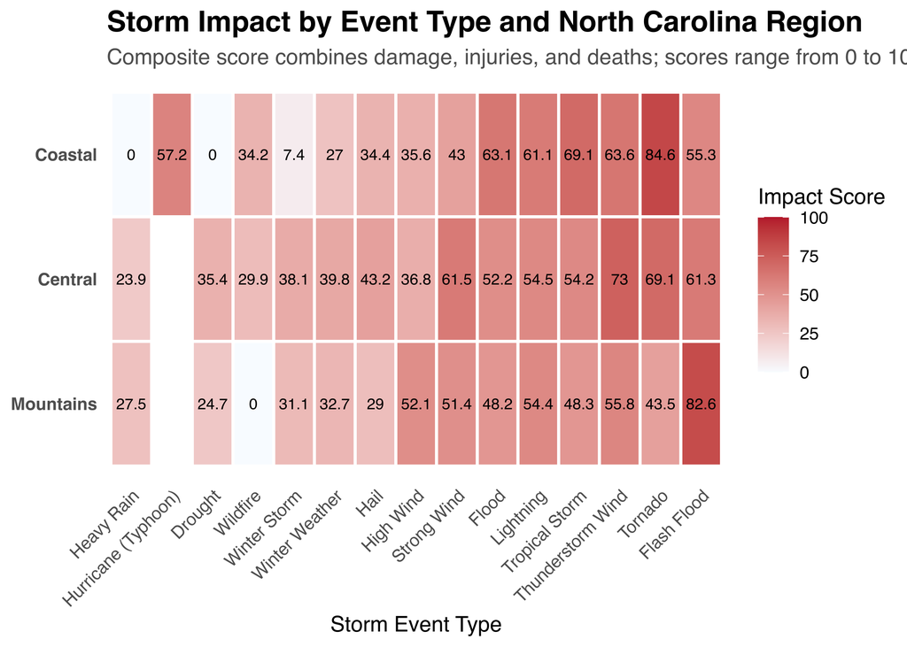

```r
heatmap_data <- regional_impacts_scored %>%
  filter(EVENT_TYPE %in% top_event_types) %>%
  mutate(
    REGION = factor(
      REGION,
      levels = c("mountains", "central", "coastal"),
      labels = c("Mountains", "Central", "Coastal")
    ),
    EVENT_TYPE = factor(EVENT_TYPE, levels = rev(top_event_types))
  )

plot_impact_heatmap <- function(
    data,
    value_column = IMPACT_SCORE,
    title        = "Storm Impact by Event Type and Region",
    subtitle     = "Higher scores indicate greater combined impacts",
    low_color    = "#F7FBFF",
    high_color   = "#B2182B",
    show_values  = TRUE,
    value_digits = 1
) {
  value_col <- rlang::enquo(value_column)

  p <- ggplot(data, aes(x = EVENT_TYPE, y = REGION, fill = !!value_col)) +
    geom_tile(color = "white", linewidth = 0.8) +
    scale_fill_gradient(
      low    = low_color, high   = high_color,
      limits = c(0, 100), breaks = c(0, 25, 50, 75, 100),
      name   = "Impact Score"
    ) +
    labs(title = title, subtitle = subtitle, x = "Storm Event Type", y = NULL) +
    theme_minimal(base_size = 12) +
    theme(
      plot.title      = element_text(face = "bold", size = 16),
      plot.subtitle   = element_text(color = "gray30"),
      axis.text.x     = element_text(angle = 45, hjust = 1, vjust = 1),
      axis.text.y     = element_text(face = "bold"),
      panel.grid      = element_blank(),
      legend.position = "right"
    )

  if (show_values) {
    p <- p + geom_text(
      aes(label = round(!!value_col, value_digits)),
      size = 3, color = "black"
    )
  }
  p
}

p_composite_heatmap <- plot_impact_heatmap(
  data         = heatmap_data,
  value_column = IMPACT_SCORE,
  title        = "Storm Impact by Event Type and North Carolina Region",
  subtitle     = "Composite score combines damage, injuries, and deaths; scores range from 0 to 100",
  low_color    = "#F7FBFF",
  high_color   = "#B2182B"
)

p_composite_heatmap
```

```r
ggsave(
  filename = "nc_storm_composite_impact_heatmap.png",
  plot     = p_composite_heatmap,
  path     = results_dir,
  width    = 16, height = 8, units = "in", dpi = 300
)
```

## Figure 3 — Impact Components by Region

Each panel isolates one impact dimension across the top event types and three regions. A logarithmic color scale is used because total damage values are orders of magnitude larger than injury or event counts.

[figure not shown]

```r
component_data <- regional_impacts_scored %>%
  filter(EVENT_TYPE %in% top_event_types) %>%
  select(REGION, EVENT_TYPE, EVENTS, INJURIES, DEATHS, TOTAL_DAMAGE) %>%
  pivot_longer(
    cols      = c(EVENTS, INJURIES, DEATHS, TOTAL_DAMAGE),
    names_to  = "IMPACT_TYPE",
    values_to = "VALUE"
  ) %>%
  mutate(
    REGION = factor(
      REGION,
      levels = c("mountains", "central", "coastal"),
      labels = c("Mountains", "Central", "Coastal")
    ),
    IMPACT_TYPE = factor(
      IMPACT_TYPE,
      levels = c("EVENTS", "INJURIES", "DEATHS", "TOTAL_DAMAGE"),
      labels = c("Number of Events", "Injuries", "Deaths", "Total Damage")
    ),
    EVENT_TYPE = factor(EVENT_TYPE, levels = rev(top_event_types))
  )

p_component_heatmaps <- ggplot(
  component_data,
  aes(x = EVENT_TYPE, y = REGION, fill = VALUE)
) +
  geom_tile(color = "white", linewidth = 0.6) +
  facet_wrap(~ IMPACT_TYPE, ncol = 2, scales = "free") +
  scale_fill_viridis_c(
    option = "C", trans = "log1p",
    labels = label_number(big.mark = ",", scale_cut = cut_short_scale()),
    name   = "Reported Value"
  ) +
  labs(
    title    = "Storm Impact Components by Event Type and Region",
    subtitle = "Darker cells indicate larger reported values; color scale is logarithmic",
    x        = "Storm Event Type", y = NULL
  ) +
  theme_minimal(base_size = 11) +
  theme(
    plot.title    = element_text(face = "bold", size = 16),
    plot.subtitle = element_text(color = "gray30"),
    axis.text.x   = element_text(angle = 45, hjust = 1),
    axis.text.y   = element_text(face = "bold"),
    panel.grid    = element_blank(),
    strip.text    = element_text(face = "bold")
  )

p_component_heatmaps
```

```r
ggsave(
  filename = "nc_storm_impact_components_by_region.png",
  plot     = p_component_heatmaps,
  path     = results_dir,
  width    = 16, height = 10, units = "in", dpi = 300
)
```

## Figure 4 — Overall Impact Ranking

Composite scores are summed across all three regions to rank event types statewide. This collapses regional variation to highlight the highest-burden event types across North Carolina.

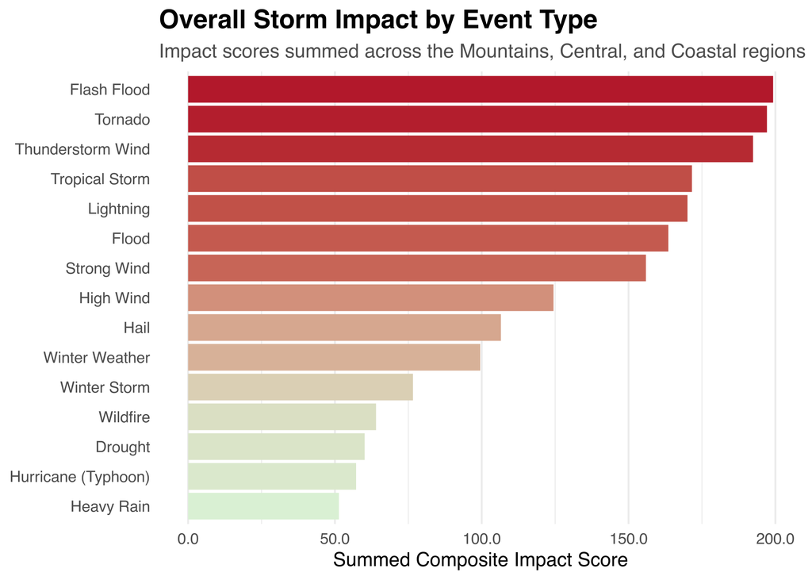

```r
plot_overall_impact <- function(data, top_n = 15, fill_low = "#D9F0D3", fill_high = "#B2182B") {
  data %>%
    slice_max(order_by = OVERALL_IMPACT_SCORE, n = top_n, with_ties = FALSE) %>%
    mutate(EVENT_TYPE = fct_reorder(EVENT_TYPE, OVERALL_IMPACT_SCORE)) %>%
    ggplot(aes(x = EVENT_TYPE, y = OVERALL_IMPACT_SCORE, fill = OVERALL_IMPACT_SCORE)) +
    geom_col() +
    coord_flip() +
    scale_fill_gradient(low = fill_low, high = fill_high, guide = "none") +
    scale_y_continuous(labels = label_number(accuracy = 0.1)) +
    labs(
      title    = "Overall Storm Impact by Event Type",
      subtitle = "Impact scores summed across the Mountains, Central, and Coastal regions",
      x        = NULL,
      y        = "Summed Composite Impact Score"
    ) +
    theme_minimal(base_size = 12) +
    theme(
      plot.title         = element_text(face = "bold", size = 16),
      plot.subtitle      = element_text(color = "gray30"),
      panel.grid.major.y = element_blank()
    )
}

p_overall_impact <- plot_overall_impact(data = overall_event_impact, top_n = 15)
p_overall_impact
```

```r
ggsave(
  filename = "nc_storm_overall_impact_by_event_type.png",
  plot     = p_overall_impact,
  path     = results_dir,
  width    = 12, height = 9, units = "in", dpi = 300
)
```

## Figure 5 — Regional Comparison

The same top 15 event types are shown side by side for each region, preserving the geographic variation that the statewide ranking in Figure 4 collapses.

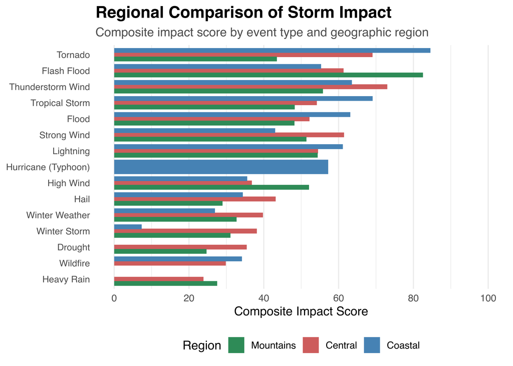

```r
regional_comparison_data <- regional_impacts_scored %>%
  filter(EVENT_TYPE %in% top_event_types) %>%
  mutate(
    REGION = factor(
      REGION,
      levels = c("mountains", "central", "coastal"),
      labels = c("Mountains", "Central", "Coastal")
    ),
    EVENT_TYPE = fct_reorder(EVENT_TYPE, IMPACT_SCORE, .fun = max)
  )

p_regional_comparison <- ggplot(
  regional_comparison_data,
  aes(x = EVENT_TYPE, y = IMPACT_SCORE, fill = REGION)
) +
  geom_col(position = position_dodge(width = 0.8)) +
  coord_flip() +
  scale_fill_manual(
    values = c("Mountains" = "#2E8B57", "Central" = "#CD5C5C", "Coastal" = "#4682B4")
  ) +
  scale_y_continuous(limits = c(0, 100), breaks = seq(0, 100, by = 20)) +
  labs(
    title    = "Regional Comparison of Storm Impact",
    subtitle = "Composite impact score by event type and geographic region",
    x        = NULL, y = "Composite Impact Score", fill = "Region"
  ) +
  theme_minimal(base_size = 12) +
  theme(
    plot.title         = element_text(face = "bold", size = 16),
    plot.subtitle      = element_text(color = "gray30"),
    axis.text.y        = element_text(size = 9),
    panel.grid.major.y = element_blank(),
    legend.position    = "bottom"
  )

p_regional_comparison
```

```r
ggsave(
  filename = "nc_storm_regional_impact_comparison.png",
  plot     = p_regional_comparison,
  path     = results_dir,
  width    = 14, height = 10, units = "in", dpi = 300
)
```

## Figure 6 — Economic Damage by Region

Property and crop damage are shown separately for each region, in millions of dollars, aggregated across all recorded storm events.

[figure not shown]

```r
damage_by_region <- regional_impacts_scored %>%
  group_by(REGION) %>%
  summarise(
    PROPERTY_DAMAGE = sum(PROPERTY_DAMAGE, na.rm = TRUE),
    CROP_DAMAGE     = sum(CROP_DAMAGE,     na.rm = TRUE),
    .groups         = "drop"
  ) %>%
  mutate(
    REGION = factor(
      REGION,
      levels = c("mountains", "central", "coastal"),
      labels = c("Mountains", "Central", "Coastal")
    )
  ) %>%
  pivot_longer(
    cols      = c(PROPERTY_DAMAGE, CROP_DAMAGE),
    names_to  = "DAMAGE_TYPE",
    values_to = "DAMAGE"
  ) %>%
  mutate(
    DAMAGE_TYPE = recode(
      DAMAGE_TYPE,
      PROPERTY_DAMAGE = "Property Damage",
      CROP_DAMAGE     = "Crop Damage"
    )
  )

p_damage_by_region <- ggplot(damage_by_region, aes(x = REGION, y = DAMAGE, fill = DAMAGE_TYPE)) +
  geom_col(position = "dodge") +
  scale_y_continuous(labels = dollar_format(scale = 1e-6, suffix = "M")) +
  scale_fill_manual(values = c("Property Damage" = "#8C2D04", "Crop Damage" = "#31A354")) +
  labs(
    title    = "Reported Property and Crop Damage by Region",
    subtitle = "Aggregate NOAA damage estimates across all recorded storm events",
    x        = NULL, y = "Damage (millions of dollars)", fill = "Damage Type"
  ) +
  theme_minimal(base_size = 12) +
  theme(
    plot.title      = element_text(face = "bold", size = 16),
    plot.subtitle   = element_text(color = "gray30"),
    legend.position = "bottom"
  )

p_damage_by_region
```

```r
ggsave(
  filename = "nc_storm_damage_by_region.png",
  plot     = p_damage_by_region,
  path     = results_dir,
  width    = 11, height = 8, units = "in", dpi = 300
)
```

## Figure 7 — Human Impacts by Region

Total storm-related injuries and deaths are compared across the three regions, drawn from NOAA storm event records.

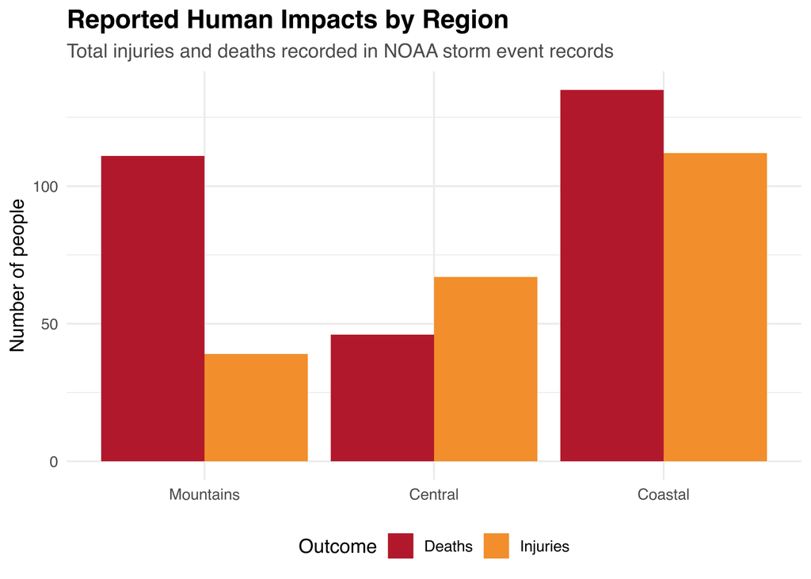

```r
human_impacts_by_region <- regional_impacts_scored %>%
  group_by(REGION) %>%
  summarise(
    INJURIES = sum(INJURIES, na.rm = TRUE),
    DEATHS   = sum(DEATHS,   na.rm = TRUE),
    .groups  = "drop"
  ) %>%
  mutate(
    REGION = factor(
      REGION,
      levels = c("mountains", "central", "coastal"),
      labels = c("Mountains", "Central", "Coastal")
    )
  ) %>%
  pivot_longer(
    cols = c(INJURIES, DEATHS), names_to = "OUTCOME", values_to = "COUNT"
  ) %>%
  mutate(OUTCOME = recode(OUTCOME, INJURIES = "Injuries", DEATHS = "Deaths"))

p_human_impacts <- ggplot(human_impacts_by_region, aes(x = REGION, y = COUNT, fill = OUTCOME)) +
  geom_col(position = "dodge") +
  scale_y_continuous(labels = label_number(big.mark = ",")) +
  scale_fill_manual(values = c("Injuries" = "#F28E2B", "Deaths" = "#B2182B")) +
  labs(
    title    = "Reported Human Impacts by Region",
    subtitle = "Total injuries and deaths recorded in NOAA storm event records",
    x        = NULL, y = "Number of people", fill = "Outcome"
  ) +
  theme_minimal(base_size = 12) +
  theme(
    plot.title      = element_text(face = "bold", size = 16),
    plot.subtitle   = element_text(color = "gray30"),
    legend.position = "bottom"
  )

p_human_impacts
```

```r
ggsave(
  filename = "nc_storm_human_impacts_by_region.png",
  plot     = p_human_impacts,
  path     = results_dir,
  width    = 11, height = 8, units = "in", dpi = 300
)
```

## Key Results

### Top Event Types by Overall Impact

The 10 highest-impact event types statewide, ranked by summed composite score across all three regions.

```r
format_damage <- function(x) {
  case_when(
    x >= 1e9 ~ paste0("$", round(x / 1e9, 1), "B"),
    x >= 1e6 ~ paste0("$", round(x / 1e6, 1), "M"),
    x >= 1e3 ~ paste0("$", round(x / 1e3, 0), "K"),
    TRUE     ~ paste0("$", round(x, 0))
  )
}

overall_event_impact %>%
  slice_head(n = 10) %>%
  mutate(
    OVERALL_IMPACT_SCORE = round(OVERALL_IMPACT_SCORE, 1),
    TOTAL_DAMAGE         = format_damage(TOTAL_DAMAGE)
  ) %>%
  rename(
    "Event Type"          = EVENT_TYPE,
    "Impact Score"        = OVERALL_IMPACT_SCORE,
    "Total Events"        = TOTAL_EVENTS,
    "Total Injuries"      = TOTAL_INJURIES,
    "Total Deaths"        = TOTAL_DEATHS,
    "Total Damage (Est.)" = TOTAL_DAMAGE
  ) %>%
  DT::datatable(
    rownames = FALSE,
    class    = "display compact",
    options  = list(dom = "t", pageLength = 10, scrollX = TRUE)
  )
```

| Event Type | Impact Score | Total Events | Total Injuries | Total Deaths | Total Damage (Est.) |
| --- | --- | --- | --- | --- | --- |
| Flash Flood | 199.2 | 1800 | 6 | 105 | $2.4B |
| Tornado | 197.1 | 339 | 90 | 9 | $445.1M |
| Thunderstorm Wind | 192.4 | 7002 | 62 | 10 | $63.7M |
| Tropical Storm | 171.6 | 363 | 4 | 25 | $518.5M |
| Lightning | 170.1 | 112 | 35 | 11 | $4.4M |
| Flood | 163.6 | 438 | 1 | 28 | $1.4B |
| Strong Wind | 155.9 | 255 | 15 | 9 | $35M |
| High Wind | 124.5 | 327 | 1 | 4 | $47.4M |
| Hail | 106.5 | 1488 | 0 | 0 | $112.9M |
| Winter Weather | 99.5 | 1111 | 2 | 4 | $355K |

### Top Region × Event Combinations

The 15 highest-scoring region × event type combinations, preserving the geographic breakdown.

```r
regional_impacts_scored %>%
  arrange(desc(IMPACT_SCORE)) %>%
  slice_head(n = 15) %>%
  select(REGION, EVENT_TYPE, IMPACT_SCORE, EVENTS, INJURIES, DEATHS, TOTAL_DAMAGE) %>%
  mutate(
    REGION       = str_to_title(REGION),
    IMPACT_SCORE = round(IMPACT_SCORE, 1),
    TOTAL_DAMAGE = format_damage(TOTAL_DAMAGE)
  ) %>%
  rename(
    "Region"              = REGION,
    "Event Type"          = EVENT_TYPE,
    "Impact Score"        = IMPACT_SCORE,
    "Events"              = EVENTS,
    "Injuries"            = INJURIES,
    "Deaths"              = DEATHS,
    "Total Damage (Est.)" = TOTAL_DAMAGE
  ) %>%
  DT::datatable(
    rownames = FALSE,
    class    = "display compact",
    options  = list(dom = "t", pageLength = 15, scrollX = TRUE)
  )
```

| Region | Event Type | Impact Score | Events | Injuries | Deaths | Total Damage (Est.) |
| --- | --- | --- | --- | --- | --- | --- |
| Coastal | Tornado | 84.6 | 198 | 71 | 6 | $320M |
| Mountains | Flash Flood | 82.6 | 252 | 5 | 78 | $2.1B |
| Central | Thunderstorm Wind | 73 | 3740 | 30 | 7 | $22.2M |
| Coastal | Tropical Storm | 69.1 | 224 | 3 | 18 | $358M |
| Central | Tornado | 69.1 | 101 | 18 | 2 | $121M |
| Coastal | Thunderstorm Wind | 63.6 | 2358 | 25 | 0 | $38.4M |
| Coastal | Flood | 63.1 | 113 | 0 | 24 | $1B |
| Central | Strong Wind | 61.5 | 159 | 5 | 7 | $21.6M |
| Central | Flash Flood | 61.3 | 762 | 1 | 12 | $214.9M |
| Coastal | Lightning | 61.1 | 47 | 10 | 8 | $2.4M |

[output cut: 5 more lines]

# Export

Processed datasets are written to `results_dir` for downstream use or sharing.

```
Analysis complete. Outputs saved to:
 /Users/kentalee/Documents/KALProjects/UNCProjects/CarolinaDataChallenge_2026/outs
```